# HW 13: Strings and things

Hayley Laubinger

02 August 2020

### Load Libraries

```r
library(tidyverse)
library(here)
library(ggthemes)
library(gghighlight)
```

## Part 1: DNA strings

### import data

```r
beta_gliadin_raw <- read_lines(here("Data", "beta_gliadin.txt"),skip=1)
beta_gliadin_raw
```

```
 [1] "\t\t1 aatttgacat gcacagctcc tgaccctgcc aatattgttg cagctgcgct cgcaagcctt"
 [2] "       61 tgcgtagatg atcactttat atgatttgtg taaaaccaaa ataagatcta caaacgaata"
 [3] "      121 gaagctagag cgtaccttgg cgtgcacaca cattgcaagc catacctaac cttgataagt"
 [4] "      181 gttaatgact tgtacaacat atacatcact taagacaagt aaaagcgatt tgatgagtca"
 [5] "      241 tggtctatca aagcaagcca cattactagt ctaatccatc ttaacaggtc acgcatgatt"
 [6] "      301 acaatcttgt ttgtgtgcaa gtcaagccta tctagtttac acgtaacaac ttgtaagaac"
 [7] "      361 attaccaaaa gttgatgttg ctaataagtg tagaacacct acaacactga catgtaaaag"
 [8] "      421 aatttgatga gtcatggcct actaaagcaa gttacattac tagtcttatg tatcttaaca"
 [9] "      481 tgccacacaa gattacaaac taagttctgt ggccagccat gcttatctag tttatgtgta"
[10] "      541 aaaatttgca aacattacaa acttagtttc agaaaagtag gcaatctaga ttagtgtttg"
[11] "      601 agttgtaaag tgaacaagat gagtcatgcg tgttatcaca cctttttggt ggtggaatga"
[12] "      661 tagtgcaaca acaacggaac tttcaatgac tagtccaaga atacacttgt aagtagtgcc"
[13] "      721 accaaacaca acataccaaa ttatgatttt gggaagcatc caaacacttt acacacaagc"
[14] "      781 aaatgccaat tgtgaaagag atcatgccat gacagctata aataggcccg catcgatgat"
[15] "      841 gatcatcctt cctcatccat cattctcata agtagagtgc atcattcaag gcaagcaagc"
```

[output cut: 41 more lines]

Data matches the format from the notes

### Replace whitespace and digits with nothing. Printe results

```r
beta_gliadin_cleaned <- str_replace_all(beta_gliadin_raw, "\\d", "") %>%
  str_replace_all("\\s", "")
beta_gliadin_cleaned
```

```
 [1] "aatttgacatgcacagctcctgaccctgccaatattgttgcagctgcgctcgcaagcctt"
 [2] "tgcgtagatgatcactttatatgatttgtgtaaaaccaaaataagatctacaaacgaata"
 [3] "gaagctagagcgtaccttggcgtgcacacacattgcaagccatacctaaccttgataagt"
 [4] "gttaatgacttgtacaacatatacatcacttaagacaagtaaaagcgatttgatgagtca"
 [5] "tggtctatcaaagcaagccacattactagtctaatccatcttaacaggtcacgcatgatt"
 [6] "acaatcttgtttgtgtgcaagtcaagcctatctagtttacacgtaacaacttgtaagaac"
 [7] "attaccaaaagttgatgttgctaataagtgtagaacacctacaacactgacatgtaaaag"
 [8] "aatttgatgagtcatggcctactaaagcaagttacattactagtcttatgtatcttaaca"
 [9] "tgccacacaagattacaaactaagttctgtggccagccatgcttatctagtttatgtgta"
[10] "aaaatttgcaaacattacaaacttagtttcagaaaagtaggcaatctagattagtgtttg"
[11] "agttgtaaagtgaacaagatgagtcatgcgtgttatcacacctttttggtggtggaatga"
[12] "tagtgcaacaacaacggaactttcaatgactagtccaagaatacacttgtaagtagtgcc"
[13] "accaaacacaacataccaaattatgattttgggaagcatccaaacactttacacacaagc"
[14] "aaatgccaattgtgaaagagatcatgccatgacagctataaataggcccgcatcgatgat"
[15] "gatcatccttcctcatccatcattctcataagtagagtgcatcattcaaggcaagcaagc"
```

[output cut: 41 more lines]

Matches data in notes and is 56 lines long

### Use ‘str_c’ to collapse the strings

```r
beta_gliadan_collapsed <- str_c(beta_gliadin_cleaned,collapse ="")
beta_gliadan_collapsed
```

```
[1] "aatttgacatgcacagctcctgaccctgccaatattgttgcagctgcgctcgcaagcctt…"
```

Matches line in the notes

### Convert it to upper case with str_to_upper().

```r
beta_gliadan_upper <- str_to_upper(beta_gliadan_collapsed)
beta_gliadan_upper
```

```
[1] "AATTTGACATGCACAGCTCCTGACCCTGCCAATATTGTTGCAGCTGCGCTCGCAAGCCTT…"
```

### Use str_length() returns the length of a string.

```r
str_length(beta_gliadan_upper)
```

```
[1] 3310
```

The DNA sequence is 3310 characters long

## Find promoter region

```r
str_count(beta_gliadan_upper, "A,C,T,G")
```

```
[1] 0
```

```r
str_count(beta_gliadan_upper, "ATG")
```

```
[1] 66
```

```r
str_count(beta_gliadan_upper, "TGA|TAA")
```

```
[1] 99
```

### Assign the two motif sequences to variables caat_box and tata_box

```r
caat_box<- "CCAAT"
tata_box<- "CTATAA"
```

### count the number

```r
str_count(beta_gliadan_upper,c(caat_box,tata_box))
```

```
[1] 4 1
```

There are 4 “CCAAT” and 1 “CTATAA”

### Make a search string called caat_seq and count number of sequences

```r
caat_seq<- "CCAAT.{100,150}ATG"
str_count(beta_gliadan_upper, caat_seq)
```

```
[1] 2
```

There are 2 possible sequences for a string that begins with “CCAAT” and ends with “ATG”

### Make a searcg string called tata_seq and count the number of sequences

```r
tata_seq<- "CTATAA.{50,100}ATG"
str_count(beta_gliadan_upper, tata_seq)
```

```
[1] 1
```

There is 1 sequence.

### Use str_extract_all to extract all of the caat_seq sequences

```r
caat_seq_all <- str_extract_all(beta_gliadan_upper,caat_seq,simplify = TRUE)
str_length(caat_seq_all)
```

```
[1] 139 148
```

The two lengths are 139 and 148.

### Use str_which() to find which caat_seq has the tata_box sequence

```r
str_which(caat_seq_all,tata_seq)
```

```
[1] 1
```

Promotor sequence is 1.

### Print promotor and determine it’s length.

```r
promotor<- str_sub(caat_seq_all)
promotor[1]
```

```
[1] "CCAATTGTGAAAGAGATCATGCCATGACAGCTATAAATAGGCCCGCATCGATGATGATCATCCTTCCTCATCCATCATTCTCATAAGTAGAGTGCATCATTCAAGGCAAGCAAGCAGTGGTCAATACAAATCCATCATG"
```

```r
str_length(promotor)
```

```
[1] 139 148
```

## Part 2: Ants

### import ants data

```r
ants_data <- read_csv(here("Data", "ants.csv"))
ants_data
```

| year | season | seas.code | trt | plot | sample | Aphaenogaster.treatae | Brachymyrmex.depilis | Camponotus.castaneus | Crematogaster.cerasi | Crematogaster.lineolata | Crematogaster.missuriensis | Dolichoderus.plagiatus | Dorymyrmex.flavus | Forelius.pruinosus | Formica.dolosa | Hypoponera.opacior | Monomorium.minimum | Neivamyrmex.nigrescens | Neivamyrmex.opacithorax | Nylanderia.terricola | Nylanderia.trageri | Pheidole.morrisi | Strumigenys.louisianae | Tapimoma.sessile | Temnothorax.pergandei | Trachymyrmex.septentrionalis |
| --- | --- | --- | --- | --- | --- | --- | --- | --- | --- | --- | --- | --- | --- | --- | --- | --- | --- | --- | --- | --- | --- | --- | --- | --- | --- | --- |
| 2010 | May | 1 | Pre-burned | 6A | 1 | 0 | 1 | 0 | 0 | 2 | 2 | 0 | 0 | 0 | 1 | 0 | 0 | 0 | 0 | 0 | 0 | 0 | 0 | 0 | 0 | 0 |
| 2010 | May | 1 | Pre-burned | 6A | 2 | 0 | 0 | 1 | 0 | 0 | 1 | 0 | 0 | 1 | 1 | 0 | 0 | 0 | 0 | 0 | 0 | 0 | 0 | 0 | 0 | 0 |
| 2010 | May | 1 | Pre-burned | 6A | 3 | 0 | 0 | 0 | 0 | 2 | 0 | 0 | 0 | 1 | 0 | 0 | 0 | 0 | 0 | 0 | 0 | 0 | 0 | 0 | 0 | 2 |
| 2010 | May | 1 | Pre-burned | 6A | 4 | 0 | 0 | 0 | 0 | 2 | 0 | 0 | 0 | 0 | 2 | 0 | 0 | 0 | 0 | 0 | 0 | 0 | 0 | 0 | 0 | 0 |
| 2010 | May | 1 | Pre-burned | 6A | 5 | 0 | 1 | 0 | 0 | 2 | 3 | 0 | 0 | 0 | 0 | 0 | 0 | 0 | 0 | 0 | 0 | 0 | 0 | 0 | 0 | 0 |
| 2010 | May | 1 | Pre-burned | 6A | 6 | 0 | 0 | 0 | 0 | 2 | 3 | 0 | 0 | 1 | 2 | 0 | 0 | 0 | 0 | 0 | 0 | 1 | 0 | 0 | 0 | 0 |
| 2010 | May | 1 | Pre-burned | 6A | 7 | 0 | 0 | 0 | 0 | 1 | 0 | 0 | 0 | 0 | 0 | 0 | 0 | 0 | 0 | 0 | 0 | 0 | 0 | 0 | 0 | 0 |
| 2010 | May | 1 | Pre-burned | 6A | 8 | 0 | 0 | 0 | 0 | 3 | 0 | 0 | 0 | 0 | 0 | 2 | 0 | 0 | 0 | 0 | 0 | 0 | 0 | 0 | 0 | 2 |
| 2010 | May | 1 | Pre-burned | 6A | 9 | 0 | 1 | 0 | 0 | 5 | 1 | 0 | 0 | 0 | 0 | 0 | 0 | 0 | 0 | 0 | 0 | 0 | 0 | 0 | 0 | 1 |
| 2010 | May | 1 | Pre-burned | 6A | 10 | 0 | 0 | 0 | 0 | 0 | 0 | 0 | 0 | 0 | 0 | 0 | 0 | 0 | 0 | 0 | 0 | 0 | 0 | 0 | 0 | 0 |

[output cut: 350 more lines]

### Wrangle the data

```r
(ants_data_wrangled <- ants_data %>%
   pivot_longer(names_to = "species",
                values_to = "abundance",
                matches("[A-Z].+\\..+",ignore.case = FALSE)) %>%
   select("year", "species", "abundance") %>%
  mutate(species = str_replace(species,
                                "(.{4}).*\\.(.{4}).*", "\\1\\2"),
          year = factor(year,
                        ordered = TRUE,
                        levels = c(2010, 2011))) %>%
   group_by(year, species) %>%
   summarise(total_abundance = sum(abundance))
   )
```

| year | species | total_abundance |
| --- | --- | --- |
| 2010 | Aphatrea | 26 |
| 2010 | Bracdepi | 20 |
| 2010 | Campcast | 5 |
| 2010 | Cremcera | 5 |
| 2010 | Cremline | 127 |
| 2010 | Cremmiss | 80 |
| 2010 | Doliplag | 2 |
| 2010 | Doryflav | 6 |
| 2010 | Foreprui | 328 |
| 2010 | Formdolo | 65 |

[output cut: 32 more lines]

### Plot the data

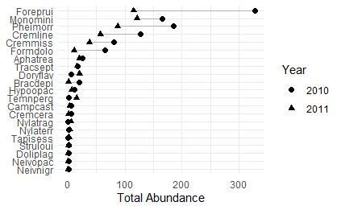

```r
ggplot(ants_data_wrangled,
       aes(x = reorder(species,total_abundance),
       y = total_abundance),
       group = species) +
  geom_line(color="Gray70")+
  geom_point(aes(shape = year),
             size = 2) +
  coord_flip() +
  labs(x = NULL, y = "Total Abundance", shape = "Year") +
theme_minimal()
```

## Part 3: Featuring Phlox Flowers

### Import and wrangle first set of data

```r
flower_size_data <- read_csv(here("data","flower_size.csv"))
flower_size_data
```

| Herbarium accession sheet | Species | Flower number | Corolla length (cm) | Corolla width throat (cm) | Mean corolla length (cm) | Standard Deviation corolla length (cm) | Mean corolla width (cm) | Standard deviation corolla width (cm) | Length width ratio |
| --- | --- | --- | --- | --- | --- | --- | --- | --- | --- |
| Acanthogilia gloriosa KANU00172801 | Acanthogilia gloriosa | 1 | 3.552 | 0.393 | NA | NA | NA | NA | NA |
| Acanthogilia gloriosa KANU00172802 | Acanthogilia gloriosa | 1 | 3.696 | 0.455 | NA | NA | NA | NA | NA |
| Acanthogilia gloriosa KANU00172802 | Acanthogilia gloriosa | 2 | 2.660 | 0.370 | NA | NA | NA | NA | NA |
| Acanthogilia gloriosa KANU00172802 | Acanthogilia gloriosa | 3 | 2.874 | 0.375 | NA | NA | NA | NA | NA |
| NA | Acanthogilia gloriosa | NA | NA | NA | 3.1955000 | 0.50587054 | 0.39825000 | 0.039101364 | 8.023854 |
| Aliciella caespitosa KSC0126229 | Aliciella caespitosa | 1 | 1.652 | 0.241 | NA | NA | NA | NA | NA |
| Aliciella caespitosa KSC0126229 | Aliciella caespitosa | 2 | 1.664 | 0.148 | NA | NA | NA | NA | NA |
| Aliciella caespitosa KSC0126229 | Aliciella caespitosa | 3 | 1.885 | 0.201 | NA | NA | NA | NA | NA |
| NA | Aliciella caespitosa | NA | NA | NA | 1.7336667 | 0.13119578 | 0.19666667 | 0.046651188 | 8.815254 |
| Aliciella formosa MO275448 | Aliciella formosa | 1 | 1.970 | 0.201 | NA | NA | NA | NA | NA |

[output cut: 990 more lines]

### wrangle flower data

```r
flower_data_wrangled <- flower_size_data %>%
  filter(!is.na('Flower number')) %>%
  select(species = 'Species', cor_length = `Corolla length (cm)`, throat_width = `Corolla width throat (cm)`) %>%
  separate(species, into = c('genus', 'species'), extra = 'drop') %>%
  group_by(genus, species) %>%
  summarise(mean_length = mean(cor_length, na.rm = TRUE),
            mean_width = mean(throat_width, na.rm = TRUE),
            max_length = max(cor_length),
            max_width = max(throat_width)
            ,.groups = 'drop')
flower_data_wrangled
```

| genus | species | mean_length | mean_width | max_length | max_width |
| --- | --- | --- | --- | --- | --- |
| Acanthogilia | gloriosa | 3.1955000 | 0.39825000 | NA | NA |
| Aliciella | caespitosa | 1.7336667 | 0.19666667 | NA | NA |
| Aliciella | formosa | 2.1168889 | 0.29722222 | NA | NA |
| Aliciella | haydenii | 1.5810000 | 0.20946667 | NA | NA |
| Aliciella | heterostyla | 1.1081667 | 0.14466667 | NA | NA |
| Aliciella | hutchinsifolia | 0.8175000 | 0.15833333 | NA | NA |
| Aliciella | latifolia | 0.5560000 | 0.09633333 | NA | NA |
| Aliciella | leptomeria | 0.5180000 | 0.09633333 | NA | NA |
| Aliciella | lottiae | 0.6360000 | 0.12833333 | NA | NA |
| Aliciella | mcvickerae | 0.6646667 | 0.14133333 | NA | NA |

[output cut: 325 more lines]

### import second data set

```r
pollinators_data <- read_csv(here("Data", "flower_pollinators.csv"))
pollinators_data
```

| Species | Color | Source | Pollinator | Source_1 |
| --- | --- | --- | --- | --- |
| Acanthogilia gloriosa | white | Hsu and Hall 2003 | hummingbird | Hsu and Hall 2003 |
| Aliciella caespitosa | red | Porter 1998 | hummingbird | Grant and Grant 1965 |
| Aliciella formosa | pink | Porter 1998 | NA | NA |
| Aliciella haydenii | pink | Porter 1998 | NA | NA |
| Aliciella heterostyla | pink | Porter 1998 | NA | NA |
| Aliciella hutchinsifolia | white | Porter 1998 | autogamous | Grant and Grant 1965 |
| Aliciella latifolia | pink | Porter 1998 | NA | NA |
| Aliciella leptomeria | white | Porter 1998 | autogamous | Grant and Grant 1965 |
| Aliciella lottiae | white | Porter 1998 | NA | NA |
| Aliciella mcvickerae | blue | Porter 1998 | NA | NA |

[output cut: 419 more lines]

### Remove columns, rows, and seperate species

```r
pollinators <- pollinators_data %>%
  select(-(Color | starts_with("Source"))) %>%
  drop_na("Pollinator") %>%
  separate(Species, into = c("genus", "species"), extra = 'drop') %>%
  separate(Pollinator, into = "Syndrome", extra = 'drop')
pollinators
```

| genus | species | Syndrome |
| --- | --- | --- |
| Acanthogilia | gloriosa | hummingbird |
| Aliciella | caespitosa | hummingbird |
| Aliciella | hutchinsifolia | autogamous |
| Aliciella | leptomeria | autogamous |
| Aliciella | micromeria | autogamous |
| Aliciella | pinnatifida | bee |
| Aliciella | subnuda | hummingbird |
| Allophyllum | divaricatum | beefly |
| Allophyllum | gilioides | autogamous |
| Allophyllum | glutinosum | bee |

[output cut: 182 more lines]

### Join 2 datasets using inner_join to join smaller to larger

```r
flower_joined_data <- flower_data_wrangled %>%
  inner_join(pollinators)
flower_joined_data
```

| genus | species | mean_length | mean_width | max_length | max_width | Syndrome |
| --- | --- | --- | --- | --- | --- | --- |
| Acanthogilia | gloriosa | 3.1955000 | 0.39825000 | NA | NA | hummingbird |
| Aliciella | caespitosa | 1.7336667 | 0.19666667 | NA | NA | hummingbird |
| Aliciella | hutchinsifolia | 0.8175000 | 0.15833333 | NA | NA | autogamous |
| Aliciella | leptomeria | 0.5180000 | 0.09633333 | NA | NA | autogamous |
| Aliciella | micromeria | 0.2130000 | 0.04266667 | NA | NA | autogamous |
| Aliciella | pinnatifida | 0.6095000 | 0.16250000 | NA | NA | bee |
| Aliciella | subnuda | 1.5465000 | 0.22788889 | NA | NA | hummingbird |
| Allophyllum | divaricatum | 0.6503333 | 0.13866667 | NA | NA | beefly |
| Allophyllum | gilioides | 0.6114333 | 0.12063333 | 2.125 | 0.800 | autogamous |
| Allophyllum | glutinosum | 0.6850000 | 0.11450000 | NA | NA | bee |

[output cut: 171 more lines]

The two data sets are joined

### Make a scatterplot to show the relationship between mean_length (x-axis) and mean_width (y-axis)

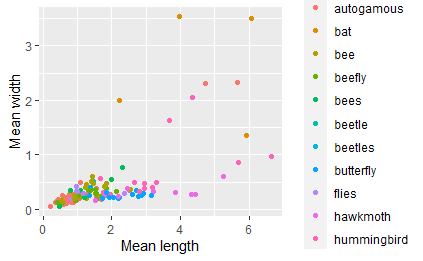

```r
flower_joined_data %>%
  ggplot() +
  geom_point(mapping = aes(x = mean_length, y = mean_width, color = Syndrome)) +
  labs(x = "Mean length", y = "Mean width")
```

### Use mutate with str_replace() and regex patterns to replace all occurences of “beetle” with “beetles,” and “bee” with “bees”.

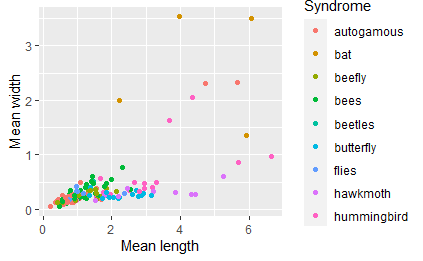

```r
flower_mutated <- flower_joined_data %>%
  mutate(Syndrome = str_replace(Syndrome, "(^be.*e$)", "\\1s")) %>%
  ggplot() +
  geom_point(mapping = aes(x = mean_length, y = mean_width, color = Syndrome)) +
  labs(x = "Mean length", y = "Mean width")
flower_mutated
```

‘Beetle’ was changed to ‘beetles’ and ‘bee’ was changed to ‘bees’.

### use mutate() with str_replace and a regex pattern to replace all instances of “beetles” or “flies” with “other insects”.

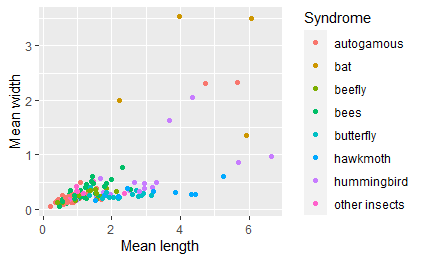

```r
flower_mutated_2 <- flower_joined_data %>%
 mutate(Syndrome = str_replace(Syndrome, "(^be.*e$)", "\\1s")) %>%
  mutate(Syndrome = str_replace(Syndrome, '(beetles|flies)', 'other insects')) %>%
  ggplot() +
  geom_point(mapping = aes(x = mean_length, y = mean_width, color = Syndrome)) +
  labs(x = "Mean length", y = "Mean width")
flower_mutated_2
```

This has added another data pointed names “other insects”, as well as removing “flies”.

### Use mutate and case_when to create a new column called syndrome_group and to change autogamous to Autogamous (upper case A), bat to Mammal, hummingbird to Bird, and everything else to Insect. Creating a new column would allow you to access the individual syndromes for future plots, when necessary.

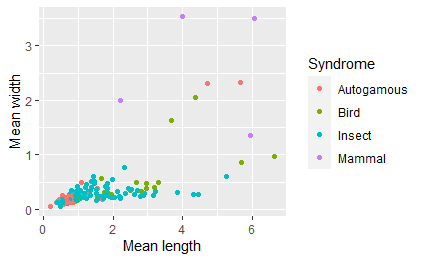

```r
flower_mutated_3 <- flower_joined_data %>%
   mutate(Syndrome = str_replace(Syndrome, "(^be.*e$)", "\\1s")) %>%
  mutate(Syndrome = str_replace(Syndrome, '(beetles|flies)', 'other insects')) %>%
  mutate(syndrome_group = case_when(
           Syndrome == "autogamous" ~ "Autogamous",
           Syndrome == "bat" ~ "Mammal",
           Syndrome == "hummingbird" ~ "Bird",
           TRUE ~ "Insect"))
flower_mutated_3 %>%
   ggplot(aes(x=mean_length,y=mean_width,color=syndrome_group))+
  geom_point()+
  labs(x="Mean length",y="Mean width",color="Syndrome")
```

```r
flower_mutated_3
```

| genus | species | mean_length | mean_width | max_length | max_width | Syndrome | syndrome_group |
| --- | --- | --- | --- | --- | --- | --- | --- |
| Acanthogilia | gloriosa | 3.1955000 | 0.39825000 | NA | NA | hummingbird | Bird |
| Aliciella | caespitosa | 1.7336667 | 0.19666667 | NA | NA | hummingbird | Bird |
| Aliciella | hutchinsifolia | 0.8175000 | 0.15833333 | NA | NA | autogamous | Autogamous |
| Aliciella | leptomeria | 0.5180000 | 0.09633333 | NA | NA | autogamous | Autogamous |
| Aliciella | micromeria | 0.2130000 | 0.04266667 | NA | NA | autogamous | Autogamous |
| Aliciella | pinnatifida | 0.6095000 | 0.16250000 | NA | NA | bees | Insect |
| Aliciella | subnuda | 1.5465000 | 0.22788889 | NA | NA | hummingbird | Bird |
| Allophyllum | divaricatum | 0.6503333 | 0.13866667 | NA | NA | beefly | Insect |
| Allophyllum | gilioides | 0.6114333 | 0.12063333 | 2.125 | 0.800 | autogamous | Autogamous |
| Allophyllum | glutinosum | 0.6850000 | 0.11450000 | NA | NA | bees | Insect |

[output cut: 171 more lines]

### Highlighting groups with gghighlight

```
Tried to calculate with group_by(), but the calculation failed.
Falling back to ungrouped filter operation...
```

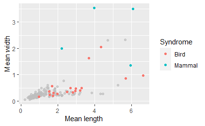

```r
flower_mutated_3 %>%
  ggplot(aes(x=mean_length,y=mean_width,color=syndrome_group))+
  geom_point()+
  labs(x="Mean length",y="Mean width",color="Syndrome")+
  gghighlight(syndrome_group=="Mammal"|syndrome_group=="Bird",use_direct_label = FALSE)
```

This highlights the mammals and birds on the graph.

### Other improvements: colors and themes

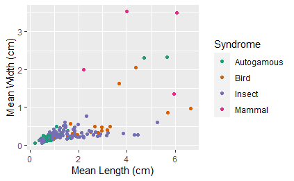

```r
flower_mutated_3 %>%
  ggplot(aes(x=mean_length,y=mean_width,color=syndrome_group))+
  geom_point()+
  scale_color_brewer(type = "qual", palette = "Dark2") +
  labs(x = "Mean Length (cm)",
       y = "Mean Width (cm)",
       color = "Syndrome")
```

This has created different colors to use for “autogamous”,“bird”,“insect”, and “mammal”.

### Change lettering

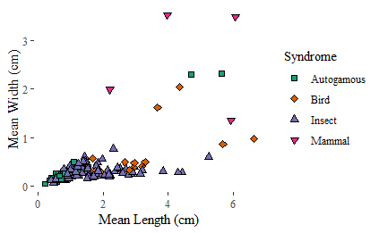

```r
flower_mutated_3 %>%
  ggplot() +
  geom_point(aes(x = mean_length,
                 y = mean_width,
                 shape = syndrome_group,
                 fill = syndrome_group),
             size = 2) +
  labs(shape = "Syndrome",
       fill = "Syndrome",
       x = "Mean Length (cm)",
       y = "Mean Width (cm)") +
  theme_tufte() +
  scale_shape_manual(values = c(22:25)) +
  scale_fill_brewer(palette = "Dark2") +
  theme(axis.text = element_text(size = 10),
        axis.title = element_text(size = 12))
```

Edits the way the data points appear. Kinda fun.

## Part 4 : Customize plots

### Plot 1

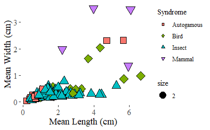

```r
flower_mutated_3 %>%
  ggplot()+
  geom_point(aes(x = mean_length,
                 y = mean_width,
                 shape = syndrome_group,
                 fill = syndrome_group,
                 size = 2)) +
    labs(shape = "Syndrome",
         fill = "Syndrome",
         x = "Mean Length (cm)",
         y = "Mean Width (cm)") +
  theme_tufte() +
  scale_shape_manual(values = c(22:25)) +
  theme(axis.text = element_text(size = 12),
        axis.title = element_text(size = 14))
```

These data points are much larger and it makes it hard to distinguish between the crowded data.

### Plot 2

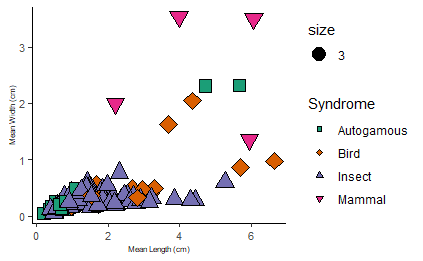

```r
flower_mutated_3 %>%
  ggplot()+
  geom_point(aes(x = mean_length,
                 y = mean_width,
                 shape = syndrome_group,
                 fill = syndrome_group,
                 size = 3)) +
    labs(shape = "Syndrome",
         fill = "Syndrome",
         x = "Mean Length (cm)",
         y = "Mean Width (cm)") +
  theme_classic() +
  scale_shape_manual(values = c(22:25)) +
   scale_fill_brewer(palette = "Dark2") +
  theme(axis.text = element_text(size = 8),
        axis.title = element_text(size = 6))
```

### Plot 3

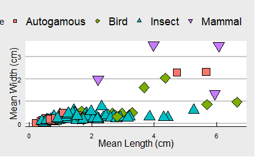

```r
flower_mutated_3 %>%
  ggplot()+
  geom_point(aes(x = mean_length,
                 y = mean_width,
                 shape = syndrome_group,
                 fill = syndrome_group,
                 size = 2)) +
    labs(shape = "Syndrome",
         fill = "Syndrome",
         x = "Mean Length (cm)",
         y = "Mean Width (cm)") +
  theme_economist_white() +
  scale_shape_manual(values = c(22:25)) +
  theme(axis.text = element_text(size = 8),
        axis.title = element_text(size = 12))
```

### Plot 4

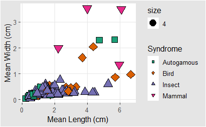

```r
flower_mutated_3 %>%
  ggplot()+
  geom_point(aes(x = mean_length,
                 y = mean_width,
                 shape = syndrome_group,
                 fill = syndrome_group,
                 size = 4)) +
    labs(shape = "Syndrome",
         fill = "Syndrome",
         x = "Mean Length (cm)",
         y = "Mean Width (cm)") +
  theme_igray() +
  scale_shape_manual(values = c(22:25)) +
   scale_fill_brewer(palette = "Dark2") +
  theme(axis.text = element_text(size = 10),
        axis.title = element_text(size =12 ))
```

#### et Vóila :D